# Gender SPI Correlation Analysis

Brian Stacy

7/5/2022

# Introduction

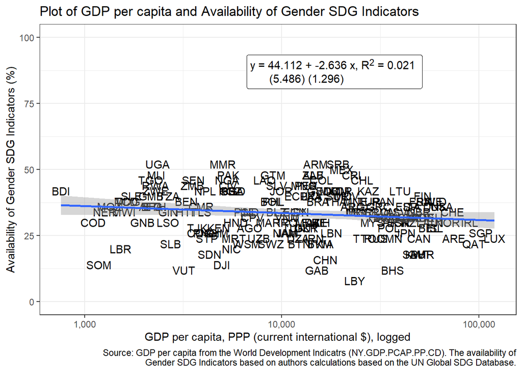

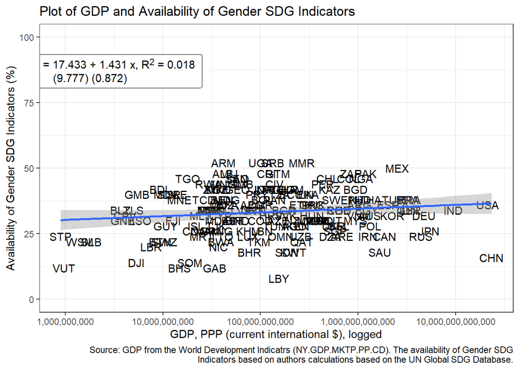

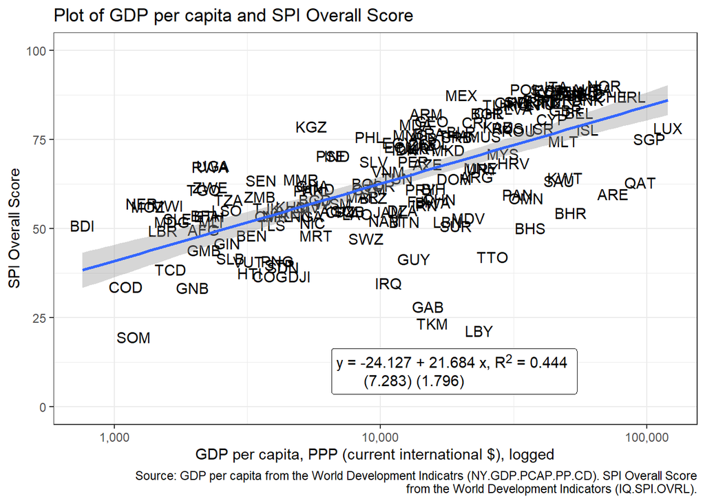

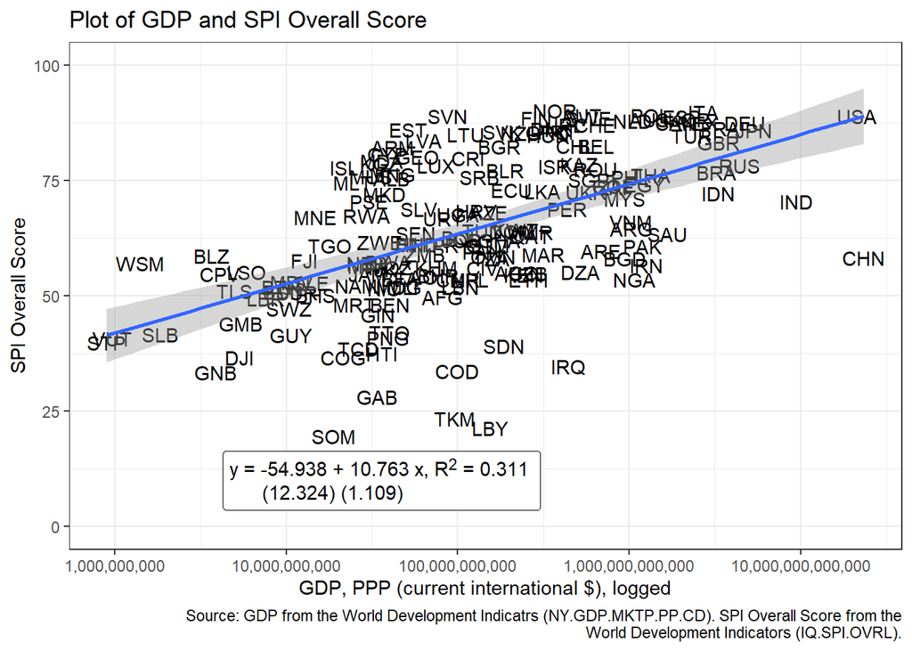

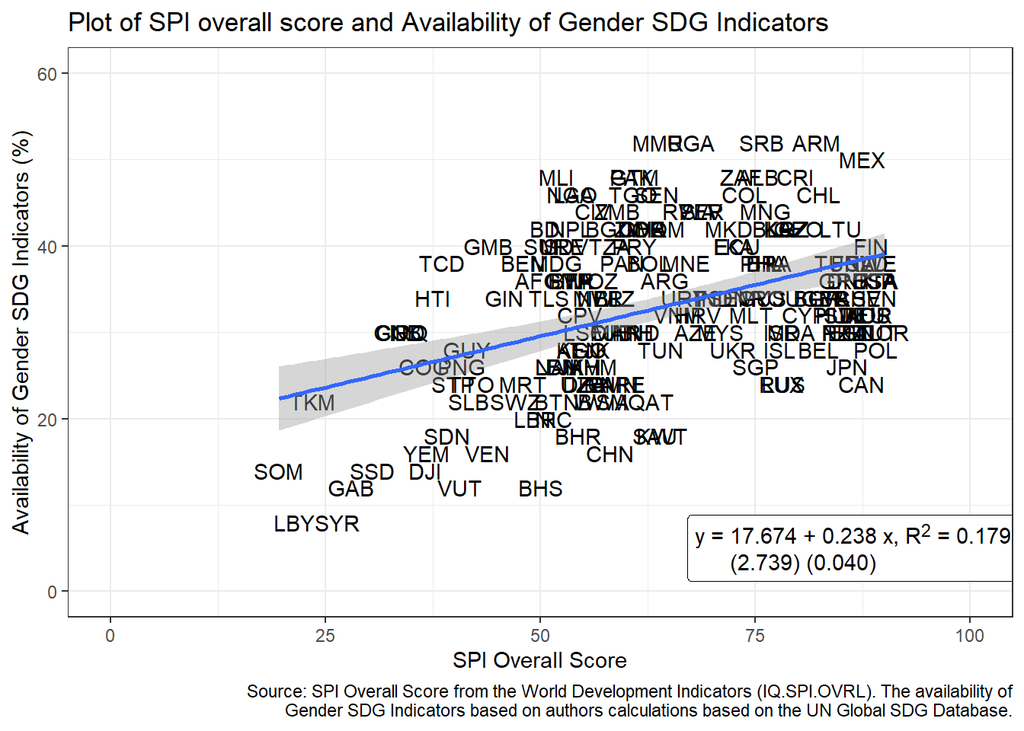

# Correlations

Can you send the correlation between GDP PC and each of the 5 subcomponents of the SPI? And then also send the correlation between the G SPI and each of the 5 subcomponents of the SPI? Along with the 3 main correlations (GDP pc & SPI, GPD pc & G SPI, and SPI & G SPI). So 13 correlations total.

Source: GDP per capita, PPP (current international $) from the World Development Indicatrs (NY.GDP.PCAP.PP.CD). SPI Overall Score from the World Development Indicators. GDP is logged. *** is significant at 0.001 level. ** is significant at 0.01 level. * is significant at 0.05 level. + is significant at 0.01 level.

## GDP per capita Correlations

Log GDP per capita & Gender SDG Availability: -0.15+.

Log GDP per capita & SPI Overall Score: 0.67***.

Log GDP per capita & SPI Pillar 1 (Data use) Score: 0.44***.

Log GDP per capita & SPI Pillar 2 (Data services) Score: 0.52***.

Log GDP per capita & SPI Pillar 3 (Data products [Overall SDG Indicator availability]) Score: 0.13+.

Log GDP per capita & SPI Pillar 4 (Data sources) Score: 0.74***.

Log GDP per capita & SPI Pillar 5 (Data infrastructure) Score: 0.71***.

## SPI Correlations

Gender SDG Availability & SPI Pillar 1 (Data use) Score: 0.53***.

Gender SDG Availability & SPI Pillar 2 (Data services) Score: 0.44***.

Gender SDG Availability & SPI Pillar 3 (Data products [Overall SDG Indicator availability]) Score: 0.69***.

Gender SDG Availability & SPI Pillar 4 (Data sources) Score: 0.34***.

Gender SDG Availability & SPI Pillar 5 (Data infrastructure) Score: 0.25**.

# Regression Analysis

```
## [1] 0.593287
```

```
## [1] -0.191638
```

```
##
## Call:
## lm(formula = availability ~ log10(NY.GDP.PCAP.PP.CD) + IQ.SPI.OVRL,
##     data = combined_df)
##
## Residuals:
##      Min       1Q   Median       3Q      Max
## -17.8422  -5.1557  -0.5515   5.5251  15.9840
##
## Coefficients:
##                           Estimate Std. Error t value Pr(>|t|)
## (Intercept)               55.25574    4.64202  11.903  < 2e-16 ***
## log10(NY.GDP.PCAP.PP.CD) -12.65157    1.46751  -8.621 6.13e-15 ***
## IQ.SPI.OVRL                0.46190    0.04509  10.244  < 2e-16 ***
## ---
## Signif. codes:  0 '***' 0.001 '**' 0.01 '*' 0.05 '.' 0.1 ' ' 1
##
## Residual standard error: 7.052 on 160 degrees of freedom
##   (4 observations deleted due to missingness)
## Multiple R-squared:  0.409,  Adjusted R-squared:  0.4017
## F-statistic: 55.37 on 2 and 160 DF,  p-value: < 2.2e-16
```

```
##
## Call:
## lm(formula = availability ~ IQ.SPI.OVRL, data = combined_df)
##
## Residuals:
##     Min      1Q  Median      3Q     Max
## -17.580  -6.680  -1.341   6.340  19.181
##
## Coefficients:
##             Estimate Std. Error t value Pr(>|t|)
## (Intercept)  17.6737     2.6173   6.753 2.36e-10 ***
## IQ.SPI.OVRL   0.2375     0.0396   5.998 1.22e-08 ***
## ---
## Signif. codes:  0 '***' 0.001 '**' 0.01 '*' 0.05 '.' 0.1 ' ' 1
##
## Residual standard error: 8.652 on 165 degrees of freedom
## Multiple R-squared:  0.179,  Adjusted R-squared:  0.174
## F-statistic: 35.98 on 1 and 165 DF,  p-value: 1.223e-08
```

```
##
## Call:
## lm(formula = availability ~ log(SP.POP.TOTL), data = combined_df)
##
## Residuals:
##      Min       1Q   Median       3Q      Max
## -25.6494  -6.0293   0.3335   7.0099  20.7870
##
## Coefficients:
##                  Estimate Std. Error t value Pr(>|t|)
## (Intercept)        12.785      6.959   1.837  0.06799 .
## log(SP.POP.TOTL)    1.241      0.428   2.899  0.00425 **
## ---
## Signif. codes:  0 '***' 0.001 '**' 0.01 '*' 0.05 '.' 0.1 ' ' 1
##
## Residual standard error: 9.314 on 165 degrees of freedom
## Multiple R-squared:  0.04846,    Adjusted R-squared:  0.0427
## F-statistic: 8.404 on 1 and 165 DF,  p-value: 0.004254
```

# SDG 5

For the 14 SDG 5 indicators, can you send me the distribution of countries with only 1, only 2, 3, 4, … up to all 14? So the %s will add up to 100. And remind me of the N (number of countries)

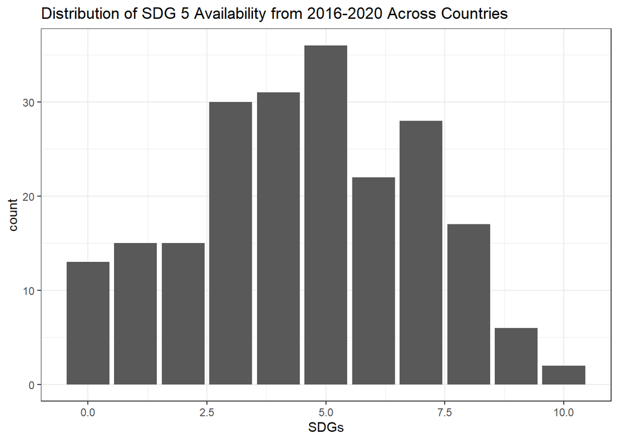

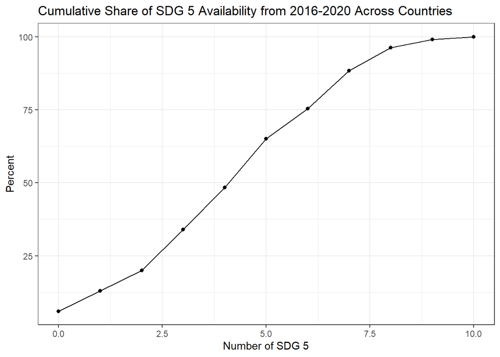

| Distribution of SDG 5 Availability from 2016-2020 Across Countries Number of SDG 5 | Distribution of SDG 5 Availability from 2016-2020 Across Countries Number of Countries | Distribution of SDG 5 Availability from 2016-2020 Across Countries Share |
| --- | --- | --- |
| 0 | 13 | 6.0465116 |
| 1 | 15 | 6.9767442 |
| 2 | 15 | 6.9767442 |
| 3 | 30 | 13.9534884 |
| 4 | 31 | 14.4186047 |
| 5 | 36 | 16.7441860 |
| 6 | 22 | 10.2325581 |
| 7 | 28 | 13.0232558 |
| 8 | 17 | 7.9069767 |
| 9 | 6 | 2.7906977 |
| 10 | 2 | 0.9302326 |